# Programming Language: Midterm

H14086030

```
## [1] "My seed is : 6030"
```

# Problem 0 (30%)

(a). Write a R program to get all prime numbers up to a given number (based on the sieve of Eratosthenes).  
(b). Write a R program to print the numbers from 1 to 100 and print “Fizz” for multiples of 3, print “Buzz” for multiples of 5, and print “FizzBuzz” for multiples of both.  
(c). Write a R program to create three vectors a,b,c with 3 integers. Combine the three vectors to become a 3×3 matrix where each column represents a vector. Print the content of the matrix.  
(d). Write a R program to compute sum, mean and product of a given vector elements.  
(e). Write a R program to create two 2x3 matrix and add, subtract, multiply and divide the matrices.

```r
# (a)
# (b)
Fizzbuzz_1<-function(x){
  result<-c()
  for(i in x){
    if(i%%3==0&&i%%5==0){
      result<-c(result,"FizzBuzz")
    }else if(i%%3==0){
      result<-c(result,"Fizz")
    }else if(i%%5==0){
      result<-c(result,"Buzz")
    }else{
      result<-c(result,i)
    }
  }
  return(result)
}
x <- c(1:100)
1:100
```

```
##   [1]   1   2   3   4   5   6   7   8   9  10  11  12  13  14  15  16  17  18
##  [19]  19  20  21  22  23  24  25  26  27  28  29  30  31  32  33  34  35  36
##  [37]  37  38  39  40  41  42  43  44  45  46  47  48  49  50  51  52  53  54
##  [55]  55  56  57  58  59  60  61  62  63  64  65  66  67  68  69  70  71  72
##  [73]  73  74  75  76  77  78  79  80  81  82  83  84  85  86  87  88  89  90
##  [91]  91  92  93  94  95  96  97  98  99 100
```

```r
Fizzbuzz_1(x)
```

```
##   [1] "1"        "2"        "Fizz"     "4"        "Buzz"     "Fizz"
##   [7] "7"        "8"        "Fizz"     "Buzz"     "11"       "Fizz"
##  [13] "13"       "14"       "FizzBuzz" "16"       "17"       "Fizz"
##  [19] "19"       "Buzz"     "Fizz"     "22"       "23"       "Fizz"
##  [25] "Buzz"     "26"       "Fizz"     "28"       "29"       "FizzBuzz"
##  [31] "31"       "32"       "Fizz"     "34"       "Buzz"     "Fizz"
##  [37] "37"       "38"       "Fizz"     "Buzz"     "41"       "Fizz"
##  [43] "43"       "44"       "FizzBuzz" "46"       "47"       "Fizz"
##  [49] "49"       "Buzz"     "Fizz"     "52"       "53"       "Fizz"
##  [55] "Buzz"     "56"       "Fizz"     "58"       "59"       "FizzBuzz"
##  [61] "61"       "62"       "Fizz"     "64"       "Buzz"     "Fizz"
##  [67] "67"       "68"       "Fizz"     "Buzz"     "71"       "Fizz"
##  [73] "73"       "74"       "FizzBuzz" "76"       "77"       "Fizz"
##  [79] "79"       "Buzz"     "Fizz"     "82"       "83"       "Fizz"
##  [85] "Buzz"     "86"       "Fizz"     "88"       "89"       "FizzBuzz"
##  [91] "91"       "92"       "Fizz"     "94"       "Buzz"     "Fizz"
##  [97] "97"       "98"       "Fizz"     "Buzz"
```

```r
# (c)
a<-c(1,3,5)
b<-c(2,4,6)
c<-c(5,7,9)
temp<-c(a,b,c)
ans<-matrix(temp,nrow=3,ncol = 3)
ans
```

```
##      [,1] [,2] [,3]
## [1,]    1    2    5
## [2,]    3    4    7
## [3,]    5    6    9
```

```r
# (d)
x<-c(5,6,7,3)
sum<-0
product<-1
for(i in x){
  sum<-sum+i
  product<-product*i
}
mean<-sum/ length(x)
cat("sum=",sum)
```

```
## sum= 21
```

```r
cat("mean=",mean)
```

```
## mean= 5.25
```

```r
cat("product=",product)
```

```
## product= 630
```

```r
# (e)
a<-matrix(7:12,nrow=2,ncol = 3)
b<-matrix(1:6,nrow=2,ncol = 3)
a+b
```

```
##      [,1] [,2] [,3]
## [1,]    8   12   16
## [2,]   10   14   18
```

```r
a-b
```

```
##      [,1] [,2] [,3]
## [1,]    6    6    6
## [2,]    6    6    6
```

```r
a*b
```

```
##      [,1] [,2] [,3]
## [1,]    7   27   55
## [2,]   16   40   72
```

```r
a/b
```

```
##      [,1] [,2] [,3]
## [1,]    7  3.0  2.2
## [2,]    4  2.5  2.0
```

# Problem 1 (10%)

Calculate the sum $\sum_{k=1}^n x^k/k$, and compare with $-ln(1-x)$, for $x=0.61, 0.71$ and $n=100, 200$.

```r
#1
n<-100
x<-.61
k<-1:n
a<-(x^k)/k
suma=sum(a)
b<--1*log(base=exp(1),(1-x))
cat("n=",n,"x=",x)
```

```
## n= 100 x= 0.61
```

```r
cat("sigma:x^k/k=",suma,"\nlog...=",b,"\n")
```

```
## sigma:x^k/k= 0.9416085
## log...= 0.9416085
```

```r
#2
n<-200
x<-.61
k<-1:n
a<-(x^k)/k
suma=sum(a)
b<--1*log(base=exp(1),(1-x))
cat("n=",n,"x=",x)
```

```
## n= 200 x= 0.61
```

```r
cat("sigma:x^k/k=",suma,"\nlog...=",b,"\n")
```

```
## sigma:x^k/k= 0.9416085
## log...= 0.9416085
```

```r
#3
n<-100
x<-.71
k<-1:n
a<-(x^k)/k
suma=sum(a)
b<--1*log(base=exp(1),(1-x))
cat("n=",n,"x=",x)
```

```
## n= 100 x= 0.71
```

```r
cat("sigma:x^k/k=",suma,"\nlog...=",b,"\n")
```

```
## sigma:x^k/k= 1.237874
## log...= 1.237874
```

```r
#4
n<-200
x<-.71
k<-1:n
a<-(x^k)/k
suma=sum(a)
b<--1*log(base=exp(1),(1-x))
cat("n=",n,"x=",x)
```

```
## n= 200 x= 0.71
```

```r
cat("sigma:x^k/k=",suma,"\nlog...=",b,"\n")
```

```
## sigma:x^k/k= 1.237874
## log...= 1.237874
```

# Problem 2 (10%)

Let $f_n$ denote the $n$th Fibonacci number.

(a). Construct a sequence of ratios of the form $f_n/f_{n-1}$, $n=1,...,30$. Does the sequence appear to be converging?  
(b). Compute the golden ratio $(1+\sqrt{5})/2$. Is the sequence converging to the ratio? Please draw a graph to support your answer.

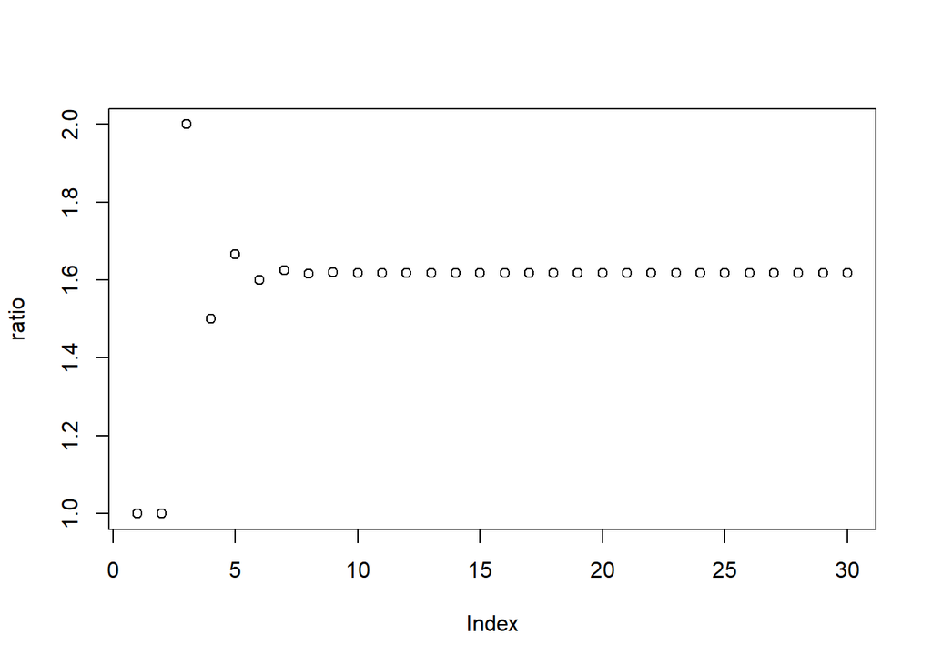

```r
#(a)
N <- 30
Fibonacci <- numeric(N)
Fibonacci[1] <- 1
Fibonacci[2] <- 1
for (n in 3:N) Fibonacci[n] <- Fibonacci[n-1] + Fibonacci[n-2]
n_f<-c(1,Fibonacci[1:29])
ratio=Fibonacci/n_f
plot(ratio)
```

```r
# yes,it appear to be converging
```

```r
#(a)
N <- 30
Fibonacci <- numeric(N)
Fibonacci[1] <- 1
Fibonacci[2] <- 1
for (n in 3:N) Fibonacci[n] <- Fibonacci[n-1] + Fibonacci[n-2]
Fibonacci#f n
```

```
##  [1]      1      1      2      3      5      8     13     21     34     55
## [11]     89    144    233    377    610    987   1597   2584   4181   6765
## [21]  10946  17711  28657  46368  75025 121393 196418 317811 514229 832040
```

```r
n_f<-c(1,Fibonacci[1:29])
n_f#f n-1
```

```
##  [1]      1      1      1      2      3      5      8     13     21     34
## [11]     55     89    144    233    377    610    987   1597   2584   4181
## [21]   6765  10946  17711  28657  46368  75025 121393 196418 317811 514229
```

```r
ratio=Fibonacci/n_f
plot(ratio)
# yes,it appear to be converging
(1+sqrt(5))/2
```

```
## [1] 1.618034
```

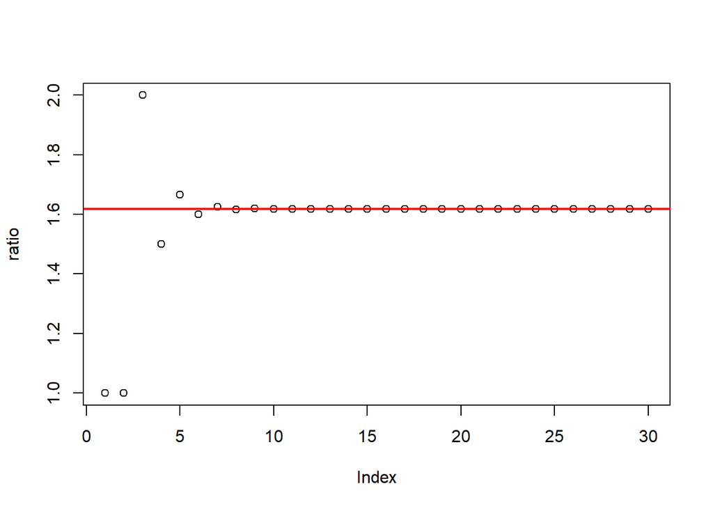

```r
abline(h = (1+sqrt(5))/2, lwd=2, col="red", xlab="n", ylab="Ratio")
```

```r
# yes,it appear to be converging to the ratio in (a)
```

# Problem 3

(a). Let $X$ be a Poisson random variable with mean $\lambda=1$. Calculate the mean and variance of $X$ using `while` loop. (8%)
(b) Let $Y$ be a geometric random variable with parameter $p$. The probability mass function of $Y is
$$Pr\{Y=y\}=(1-p)^{x-1}p,x=1,2,...,0<p<1$$
Use `repeat` loop to calculate the mean of $Y$ with $p=0.76$. (7%)

```r
#(a)
Pois_info <- function(lamba){
  k<- 0
  pois <- (exp(-1*lamba)*lamba^k)/factorial(k)
  mean<-0
  var <-0
  while(pois>10^-10||k<20){#為了避免lamba過大導致f(0)小於10^-10不符合while判斷標準導致mean=0
    mean<- mean+k*pois
    k<-k+1
    pois<- (exp(-1*lamba)*(lamba^k))/factorial(k)
  }
  k <- 0
  pois <- (exp(-1*lamba)*lamba^k)/factorial(k)
  while(pois>10^-10||k<20){
    var<- var+(k-mean)^2 *pois
    k<-k+1
    pois<- (exp(-1*lamba)*(lamba^k))/factorial(k)
  }
  return(list(mean=mean,vaiance=var))
}
Pois_info(1)
```

```
## $mean
## [1] 1
##
## $vaiance
## [1] 1
```

```r
#(b)

pr<-function(x,p=.76){(1-p)^(x-1)*p}
x<-1
mean<-0
repeat{
  mean<-mean+x*pr(x)
  if(pr(x)<10^-20)break
  x<-x+1
}
mean
```

```
## [1] 1.315789
```

# Problem 4

(a). Use a fixed-point iteration to find a root of $cox(x)-xe^x=0$. How many iteration does it take before you have an answer which is accurate in the first two digits? (5%)  
(b). Use Newton’s method to find a root of $cox(x)-xe^x=0$. How many iteration does it take before you have an answer which is accurate in the first two digits? (10%)

```r
#(b)
```

# Problem 5

Write a function that can fill the area under curve (the Exponential distribution with rate $\lambda=1$) for a given value $x > 0$ on the x-axis. The probability density function is
$$f(x)=\lambda e^{-\lambda x}, x>0$$
The user can specify the following options: (a) upper-tail or lower-tail (b) the value on the x-axis. (20%)

```r
# Ans
```

# Problem 6

Suppose that we have a function
$$f(x)=\frac{1}{\sqrt{2\pi}}e^{-\frac{(x-\mu)^2}{2}}, -\infty < x < \infty.$$
Please find the maximum of the function above using fixed-point iteration or Newton’s method. (15%)

```r
# Ans
```